# Assignment 5: House Price Prediction, Chicago

- Show All Code
- Hide All Code
- View Source

MUSA 5080 · Team Mahjong · North/South model

Chicago house-price prediction with spatial features, cross-validation, and income-group valuation diagnostics.

Author

Team Mahjong: Chenyan Zhao, Peirong Luo, Terry Xu, Xuanyu Zhou

Published

October 30, 2026

## Part 0: Setup

```r
library(tidyverse)
library(tidycensus)
library(sf)
library(caret)
library(spdep)
library(nngeo)
library(gt)
options(scipen = 999, timeout = 300, tigris_use_cache = TRUE)
theme_set(theme_minimal(base_size = 12))
knitr::opts_chunk$set(fig.width = 8, fig.height = 5, dpi = 160)
dollars <- scales::label_dollar(accuracy = 1)
percent <- scales::label_percent(accuracy = .1)
dir.create("data/assignment5/figures", recursive = TRUE, showWarnings = FALSE)
save_plot <- function(plot, name, width = 8, height = 5) {
  ggsave(file.path("data/assignment5/figures", paste0(name, ".png")), plot,
         width = width, height = height, dpi = 160, bg = "white")
  plot
}
```

**Team:** Mahjong.

### Data preparation

We combine the supplied house characteristics with location and recent-crime features, then compare the models using the same ten validation folds.

```r
source("data/assignment5/prepare_features.R", local = TRUE)
source("data/assignment5/fit_models.R", local = TRUE)
final_row <- model_log %>% filter(model == final_name)
original_row <- model_log %>% filter(model == "m10")
ward_lot_row <- model_log %>% filter(model == "E3")
```

The final model allows the lot-area coefficient to differ between northern and southern locations. Its mean-fold CV RMSE is **$179,512**. The analysis below compares its prediction errors and income-group valuation ratios with the earlier models.

## Part 1: Clean and explore

### Market-sale sample

We screen out training transfers at or below $10,000, multiple-property sales, and records without positive building area or valid coordinates. A transaction covering several properties does not identify the value of the one house whose features are recorded. There is no upper-price or upper-age cutoff. All test records remain, and missing predictors are filled inside each training fold.

```r
features$cleaning_log %>% gt() %>%
  cols_label(rule = "Rule", reason = "Reason", removed = "Removed", remaining = "Remaining") %>%
  fmt_number(columns = c(removed, remaining), decimals = 0)
```

| Rule | Reason | Removed | Remaining |
| --- | --- | --- | --- |
| Price at or below $10,000 | Remove nominal transfers | 0 | 23,200 |
| Multiple-property sale | Price covers more than one property | 1,232 | 21,968 |
| Invalid building area | Require a positive residential building area | 0 | 21,968 |
| Missing coordinates | Require a location | 0 | 21,968 |

The rules retain **21,968 training sales** out of 23,200. All 1,232 actual exclusions are multiple-property transactions; the other rules remove no records in these supplied files. We predict all **5,789 test houses**. The test set still includes **280 multiple-property transactions**, so CV on retained single-property sales does not directly validate that subgroup.

### Exploration

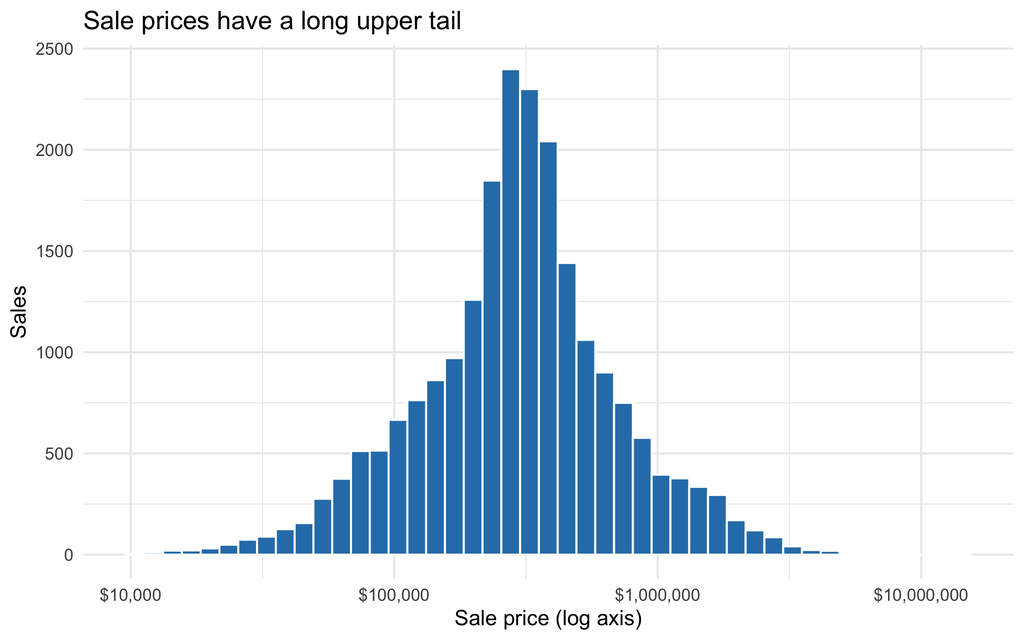

```r
p_price <- ggplot(train_raw, aes(sale_price)) +
  geom_histogram(bins = 45, fill = "#2c7fb8", color = "white") +
  scale_x_log10(labels = scales::label_dollar()) +
  labs(title = "Sale prices have a long upper tail", x = "Sale price (log axis)", y = "Sales")
save_plot(p_price, "price_distribution")
```

The plot uses a log axis for display; the regression outcome stays in dollars.

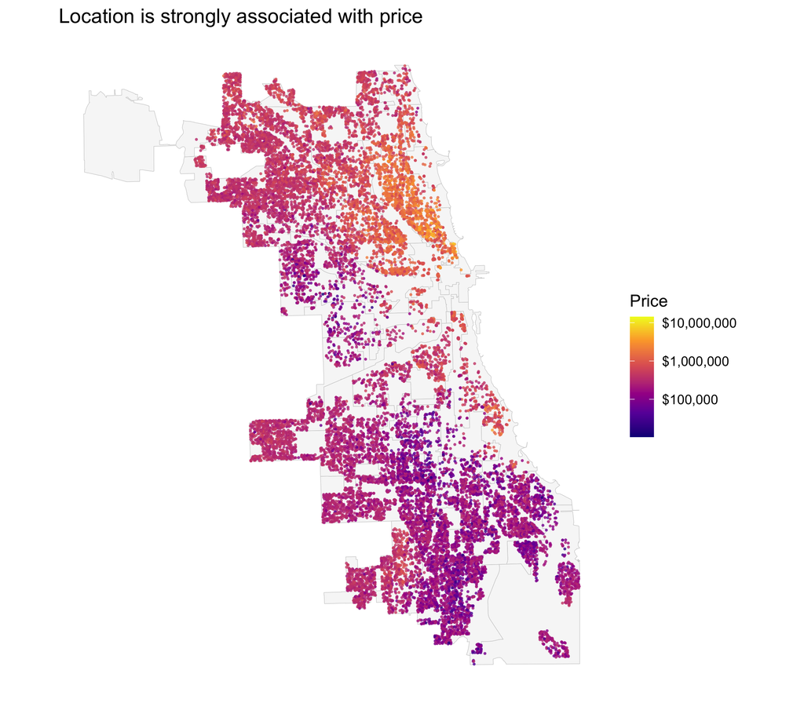

```r
p_map <- ggplot() +
  geom_sf(data = features$wards, fill = "#f7f7f7", color = "#cccccc", linewidth = .15) +
  geom_sf(data = train_raw, aes(color = sale_price), size = .35, alpha = .7) +
  scale_color_viridis_c(trans = "log10", labels = scales::label_dollar(), name = "Price", option = "C") +
  coord_sf(datum = NA) + labs(title = "Location is strongly associated with price") +
  theme(panel.grid = element_blank())
save_plot(p_map, "price_map", height = 7)
```

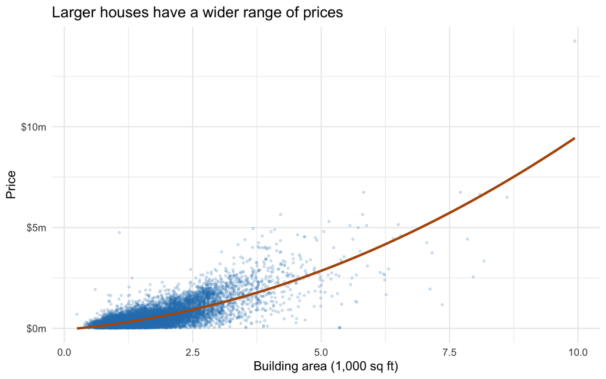

```r
p_size <- ggplot(train_raw, aes(building_000sf, sale_price)) +
  geom_point(alpha = .18, size = .7, color = "#2c7fb8") +
  geom_smooth(method = "lm", formula = y ~ x + I(x^2), se = FALSE, color = "#b35806") +
  scale_y_continuous(labels = scales::label_dollar(scale = 1e-6, suffix = "m")) +
  labs(title = "Larger houses have a wider range of prices", x = "Building area (1,000 sq ft)", y = "Price")
save_plot(p_size, "size_price")
```

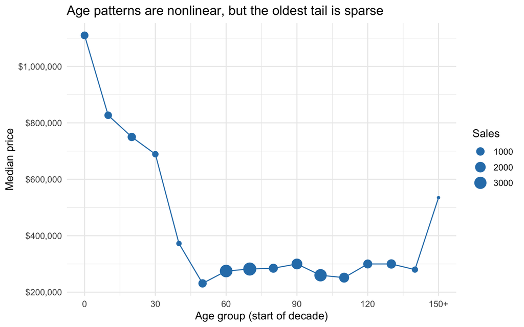

```r
age_summary <- train_raw %>% st_drop_geometry() %>%
  mutate(age_bin = if_else(building_age >= 150, 150, floor(building_age / 10) * 10)) %>%
  group_by(age_bin) %>% summarize(n = n(), median_price = median(sale_price), .groups = "drop")
p_age <- ggplot(age_summary, aes(age_bin, median_price)) +
  geom_line(color = "#2c7fb8") + geom_point(aes(size = n), color = "#2c7fb8") +
  scale_x_continuous(breaks = seq(0, 150, 30),
    labels = function(x) ifelse(x == 150, "150+", as.character(x))) +
  scale_y_continuous(labels = scales::label_dollar()) +
  labs(title = "Age patterns are nonlinear, but the oldest tail is sparse",
       x = "Age group (start of decade)", y = "Median price", size = "Sales")
save_plot(p_age, "age_price")
```

There is only one sale in the original 170–179-year group. We pool ages 150 and above for display so that one transaction is not presented as a stable age trend. No old houses are removed from modeling. The descriptive tail alone does not justify a quadratic specification.

The price map motivates place effects. The area plot motivates nonlinear terms and location-specific area slopes. We also examine low-income overvaluation using out-of-fold predictions. We retain legitimate expensive houses because they are part of the prediction task and can strongly affect dollar RMSE.

## Part 2: Build the model

### Predictors and validation

| Feature | Construction |
| --- | --- |
| House structure | Area, age, lot size, bedrooms, bathrooms, fireplace, garage, air conditioning, stories, basement, exterior and furnace |
| Transformations | Log lot area; squared area, age and downtown distance |
| Time | Year and quarter indicators |
| Broad location | Distance and east/north coordinates relative to downtown |
| Ward | 2023 Ward fixed effects and area-by-Ward interactions; sparse Wards merged geographically |
| Robbery exposure | Log count within 660 ft and log mean distance to five recent events |
| North/South | Main effect and log-lot interaction at projected `north_mi = 0` |

Ward boundaries are the 2023 geography. Crime features use events from 2023–2025 in the preceding available complete quarter, ending at least seven days before sale. Early-2023 houses have unavailable crime history within the allowed window; their values are imputed and flagged. The current historical crime extract may include later revisions: an earlier event date does not establish that the same record version was available at sale time. Income is only a retrospective diagnostic.

We use the original fixed ten folds (seed 5080), grouping identical coordinates. All models use identical retained rows, folds and five-neighbor row-standardized spatial weights. Imputation medians are learned only in each analysis fold. No features use neighboring prices, held-out prices or residuals.

### Sequential model development

Models m1–m10 form a step-by-step sequence. Each model adds or changes predictors in the preceding model, starting with house characteristics in m1 and ending with the original full model, m10.

```r
model_log %>% filter(model %in% paste0("m", 1:10)) %>%
  select(model, added, cv_rmse, moran_i, notes) %>% gt() %>%
  cols_label(model = "Model", added = "Added / changed", cv_rmse = "CV RMSE",
    moran_i = "Moran's I", notes = "Reason") %>%
  fmt_currency(columns = cv_rmse, decimals = 0) %>% fmt_number(columns = moran_i, decimals = 4)
```

| Model | Added / changed | CV RMSE | Moran's I | Reason |
| --- | --- | --- | --- | --- |
| m1 | House characteristics | $281,468 | 0.3773 | Establish a baseline using house characteristics. |
| m2 | Lot-area transformation and squared terms | $267,870 | 0.4164 | Test nonlinear area and age effects. |
| m3 | Sale year and quarter | $267,063 | 0.4189 | Account for market changes and seasonality. |
| m4 | Distance to downtown and coordinates | $235,864 | 0.3982 | Capture the citywide location pattern. |
| m5 | Ward fixed effects | $196,399 | 0.2043 | Capture price differences between Wards. |
| m6 | Area effect by Ward | $182,389 | 0.1699 | Test whether the value of extra space differs by Ward. |
| m7 | Nearby robbery count | $182,373 | 0.1696 | Test the association with nearby robberies. |
| m8 | Distance to five nearest robberies | $182,297 | 0.1688 | Measure proximity where the nearby count is zero. |
| m9 | Transformed robbery distance | $182,236 | 0.1683 | Test a nonlinear relationship with robbery distance. |
| m10 | Area-by-age interaction | $181,295 | 0.1710 | Test whether the area effect changes with age. |

### Alternative model specifications

These models test separate alternatives rather than a sequence of additions. E1–E4 each modify m10. NS adds a North/South indicator and a log-lot-area interaction to m10, allowing the lot-area coefficient to differ by region.

```r
model_log %>% filter(startsWith(model, "E") | model == "NS") %>%
  select(model, added, cv_rmse, moran_i, notes) %>% gt() %>%
  cols_label(model = "Model", added = "Added / changed", cv_rmse = "CV RMSE",
    moran_i = "Moran's I", notes = "Reason") %>%
  fmt_currency(columns = cv_rmse, decimals = 0) %>% fmt_number(columns = moran_i, decimals = 4)
```

| Model | Added / changed | CV RMSE | Moran's I | Reason |
| --- | --- | --- | --- | --- |
| E1 | Untransformed lot area | $183,013 | 0.1744 | Check whether raw lot area reduces negative predictions. |
| E2 | Alternative lot-area transformation | $182,845 | 0.1743 | Use a less steep transformation for small lots. |
| E3 | Lot-area effect by Ward | $175,758 | 0.1451 | Test whether the lot-area effect differs by Ward. |
| E4 | Remove the area squared term | $180,116 | 0.1701 | Check the influence of the area squared term. |
| NS | Lot-area effect by North/South region | $179,512 | 0.1642 | Test whether lot area has different effects in the two regions. |

## Part 3: Final model

The selected model is **NS**, with mean-fold RMSE **$179,512** and pooled OOF RMSE **$180,385**. Its mean-fold RMSE is **1.0%** lower than original m10 and **36.2%** lower than the structure-only baseline. These two RMSE summaries have different aggregation rules and are labeled separately.

```r
comparison %>% select(model, cv_rmse, pooled_oof_rmse, moran_i,
                      oof_negative, test_negative, test_min) %>% gt() %>%
  cols_label(model = "Model", cv_rmse = "Mean-fold RMSE", pooled_oof_rmse = "Pooled RMSE",
    moran_i = "Moran's I", oof_negative = "OOF negatives", test_negative = "Test negatives",
    test_min = "Minimum test prediction") %>%
  fmt_currency(columns = c(cv_rmse, pooled_oof_rmse, test_min), decimals = 0) %>%
  fmt_number(columns = moran_i, decimals = 4)
```

| Model | Mean-fold RMSE | Pooled RMSE | Moran's I | OOF negatives | Test negatives | Minimum test prediction |
| --- | --- | --- | --- | --- | --- | --- |
| m1 | $281,468 | $282,189 | 0.3773 | 146 | 34 | −$187,837 |
| m10 | $181,295 | $182,182 | 0.1710 | 56 | 12 | −$95,830 |
| NS | $179,512 | $180,385 | 0.1642 | 10 | 2 | −$42,817 |

NS reduces RMSE and residual clustering compared with m10, and decreases negative predictions from 56 to 10 in cross-validation and from 12 to 2 in the test set. E3 has a lower RMSE but produces an extreme negative test prediction of about **-$901,194**. We choose NS as a simpler geographic adjustment, while recognizing that its low-income valuation ratios are slightly worse than m10’s.

```r
# Predict sale price in dollars; R includes an intercept by default.
f_final <- sale_price ~
  # Building area (1,000 sq ft) and age (decades).
  building_000sf + age_decade +
  # Room counts, amenities, and building characteristics.
  num_bedrooms + num_full_baths + num_half_baths +
  num_fireplaces + garage_size + central_air + one_story +
  full_basement + finished_basement + brick_stone_ext + warmairfurnace +
  # Natural log of lot area; squared terms allow curved area and age effects.
  log_lot + I(building_000sf^2) + I(age_decade^2) +
  # Sale-year and quarter indicators capture market changes and seasonality.
  year_f + quarter_f +
  # Distance to downtown and signed east/north coordinates, in miles.
  downtown_mi + I(downtown_mi^2) + east_mi + north_mi +
  # Ward indicators allow different baseline prices across Wards.
  model_ward +
  # log(1 + nearby robbery count), unavailable-history flag,
  # and log(1 + mean distance to the five nearest recent robberies).
  log_robbery + crime_unavailable + log_knn5 +
  # North/South indicator allows different regional baseline prices.
  lot_zone +
  # The area coefficient may differ across Wards.
  building_000sf:model_ward +
  # The area coefficient may change with building age.
  building_000sf:age_decade +
  # The log-lot coefficient may differ between North and South.
  log_lot:lot_zone
```

The North/South boundary is fixed at `north_mi = 0`, relative to downtown. Both regions are estimated in one regression. The interaction allows the log-lot coefficient to differ between regions while sharing the other model terms.

```r
all_coefficients[[final_name]] %>% filter(term %in% c("num_full_baths", "num_bedrooms",
  "log_lot", "lot_zoneSouth", "log_lot:lot_zoneSouth", "building_000sf:age_decade")) %>%
  gt() %>% fmt_number(columns = estimate, decimals = 1)
```

| term | estimate |
| --- | --- |
| num_bedrooms | 8,414.6 |
| num_full_baths | 49,509.2 |
| log_lot | 228,514.0 |
| lot_zoneSouth | −523,880.0 |
| building_000sf:age_decade | −8,261.9 |
| log_lot:lot_zoneSouth | −163,777.0 |

```r
bath_coefficient <- coef(m_final)[["num_full_baths"]]
```

### Baseline and final residual maps

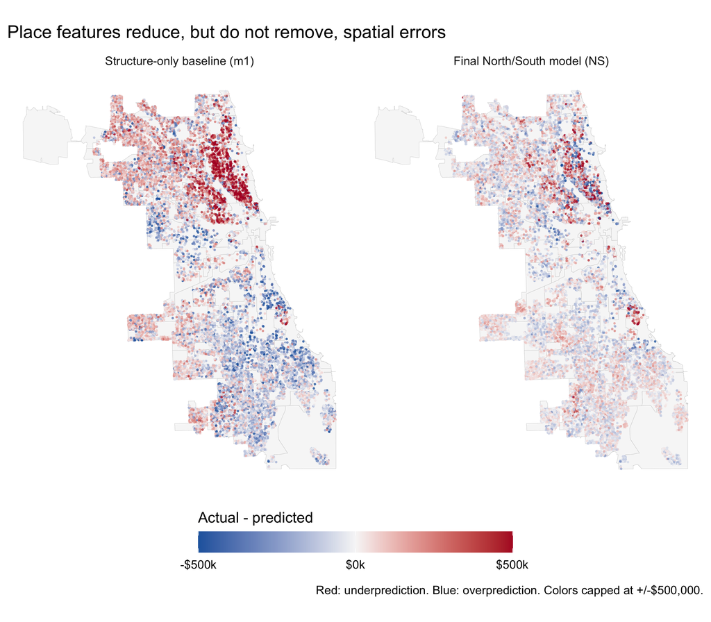

```r
residual_map <- bind_rows(
  diagnostics %>% select(id) %>% mutate(model = "Structure-only baseline (m1)", residual = diagnostics$residual_baseline),
  diagnostics %>% select(id) %>% mutate(model = "Final North/South model (NS)", residual = diagnostics$residual_final)) %>%
  mutate(model = factor(model, levels = c("Structure-only baseline (m1)", "Final North/South model (NS)")))
p_residual <- ggplot() +
  geom_sf(data = features$wards, fill = "#f7f7f7", color = "#cccccc", linewidth = .1) +
  geom_sf(data = residual_map, aes(color = residual), size = .3, alpha = .65) +
  scale_color_gradient2(low = "#2166ac", mid = "#f7f7f7", high = "#b2182b",
    limits = c(-500000, 500000), breaks = c(-500000, 0, 500000), oob = scales::squish,
    labels = scales::label_dollar(scale = 1e-3, suffix = "k"), name = "Actual - predicted",
    guide = guide_colorbar(barwidth = grid::unit(9, "cm"), title.position = "top")) +
  facet_wrap(~model) + coord_sf(datum = NA) +
  labs(title = "Place features reduce, but do not remove, spatial errors",
    caption = "Red: underprediction. Blue: overprediction. Colors capped at +/-$500,000.") +
  theme(legend.position = "bottom", panel.grid = element_blank())
save_plot(p_residual, "residual_maps", width = 10, height = 7)
```

Moran’s I falls from **0.171** for m10 to **0.164** for NS. Positive residual clustering remains; this statistic describes spatial errors, not a significance test.

## Part 4: Where it fails, and who pays

### 4A. Largest errors

```r
error_by_ward <- diagnostics %>% st_drop_geometry() %>% group_by(ward) %>%
  summarize(sales = n(), rmse = sqrt(mean(residual_final^2)),
    mean_residual = mean(residual_final), median_price = median(sale_price), .groups = "drop")
worst_ward <- error_by_ward %>% filter(sales >= 50) %>% arrange(desc(rmse)) %>% slice(1)
error_by_ward %>% filter(sales >= 50) %>% arrange(desc(rmse)) %>% slice_head(n = 6) %>%
  gt() %>% fmt_currency(columns = c(rmse, mean_residual, median_price), decimals = 0)
```

| ward | sales | rmse | mean_residual | median_price |
| --- | --- | --- | --- | --- |
| 43 | 303 | $780,189 | $4,235 | $1,810,000 |
| 2 | 120 | $557,811 | −$4,838 | $1,447,500 |
| 44 | 100 | $416,001 | $76,166 | $1,540,000 |
| 46 | 50 | $360,264 | −$150,881 | $707,950 |
| 47 | 352 | $333,391 | $663 | $1,325,000 |
| 5 | 152 | $325,481 | $2,373 | $443,500 |

Ward **43** has the largest OOF RMSE among Wards with at least 50 retained sales: **$780,189**. Its mean residual is **$4,235**. Mean errors can cancel even where individual errors are large. Unmeasured renovation, interior quality and unusual luxury properties are plausible sources of remaining errors; these diagnostics do not identify their causes.

```r
largest_errors <- diagnostics %>% st_drop_geometry() %>%
  arrange(desc(abs(residual_final))) %>% slice_head(n = 5) %>%
  select(id, ward, sale_price, pred_final, residual_final)
largest_errors %>% gt() %>%
  fmt_currency(columns = c(sale_price, pred_final, residual_final), decimals = 0)
```

| id | ward | sale_price | pred_final | residual_final |
| --- | --- | --- | --- | --- |
| 19188 | 43 | $14,250,000 | $7,235,256 | $7,014,744 |
| 7638 | 43 | $4,750,000 | $1,047,398 | $3,702,602 |
| 12182 | 42 | $5,650,000 | $2,044,159 | $3,605,841 |
| 13591 | 42 | $4,900,000 | $2,058,799 | $2,841,201 |
| 2541 | 2 | $5,650,000 | $2,918,590 | $2,731,410 |

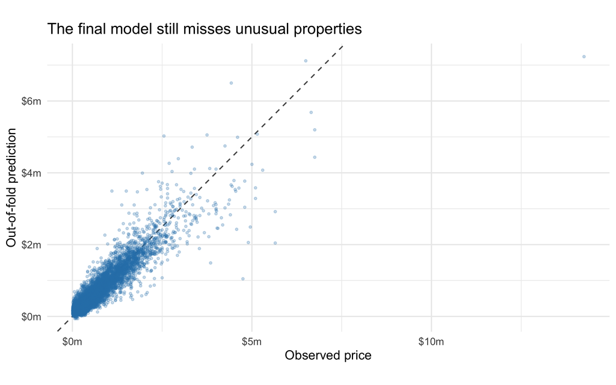

```r
p_fit <- ggplot(diagnostics, aes(sale_price, pred_final)) +
  geom_abline(intercept = 0, slope = 1, linetype = 2, color = "#555555") +
  geom_point(alpha = .25, size = .8, color = "#2c7fb8") +
  scale_x_continuous(labels = scales::label_dollar(scale = 1e-6, suffix = "m")) +
  scale_y_continuous(labels = scales::label_dollar(scale = 1e-6, suffix = "m")) +
  coord_equal() + labs(title = "The final model still misses unusual properties",
    x = "Observed price", y = "Out-of-fold prediction")
save_plot(p_fit, "observed_predicted")
```

### 4B. Neighborhood income and valuation ratios

Tract median income is from the 2023 ACS five-year table B19013 (2019–2023). Because those estimates were released after some sales, they are used only for retrospective equity diagnostics, not as predictors. The **71** records without a valid income group remain in the regression and are omitted only from the income comparison.

```r
income_summary <- income_metrics %>% filter(model %in% c("m10", "NS"))
income_summary %>% select(model, income_group, n, median_ratio, mean_ratio, share_overvalued) %>%
  gt(groupname_col = "model") %>%
  fmt_number(columns = c(median_ratio, mean_ratio), decimals = 3) %>%
  fmt_percent(columns = share_overvalued, decimals = 1)
```

| income_group | n | median_ratio | mean_ratio | share_overvalued |
| --- | --- | --- | --- | --- |
| m10 |  |  |  |  |
| Under $50k | 4641 | 1.132 | 1.574 | 57.9% |
| $50k-75k | 6175 | 1.016 | 1.277 | 51.5% |
| $75k-100k | 5312 | 0.990 | 1.107 | 48.7% |
| $100k+ | 5769 | 0.990 | 1.048 | 48.1% |
| NS |  |  |  |  |
| Under $50k | 4641 | 1.146 | 1.581 | 58.4% |
| $50k-75k | 6175 | 1.025 | 1.279 | 52.3% |
| $75k-100k | 5312 | 0.990 | 1.103 | 48.6% |
| $100k+ | 5769 | 0.991 | 1.049 | 48.4% |

The low-income median ratio rises from **1.132** to **1.146**, and the overvalued share rises from **57.9%** to **58.4%**. Thus, better overall RMSE does not improve this equity diagnostic. The low-income mean ratio is **1.581**. These ratios describe neighborhood income groups, not individual owners’ incomes.

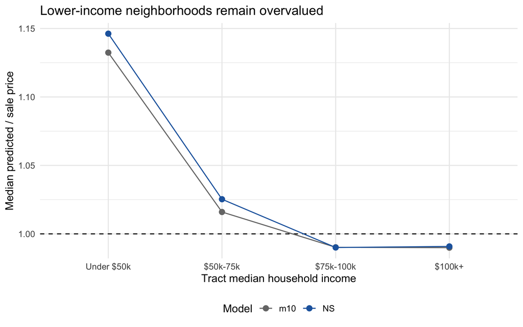

```r
p_income <- income_summary %>% mutate(model = factor(model, levels = c("m10", "NS"))) %>%
  ggplot(aes(income_group, median_ratio, color = model, group = model)) +
  geom_hline(yintercept = 1, linetype = 2) + geom_line() + geom_point(size = 2.5) +
  scale_color_manual(values = c("m10" = "#777777", "NS" = "#2166ac")) +
  labs(title = "Lower-income neighborhoods remain overvalued",
    x = "Tract median household income", y = "Median predicted / sale price", color = "Model") +
  theme(legend.position = "bottom")
save_plot(p_income, "income_ratios")
```

```r
cleaning_by_income <- features$all_sales %>% st_drop_geometry() %>% filter(split == "train") %>%
  mutate(income_group = cut(income, c(-Inf, 50000, 75000, 100000, Inf),
    labels = levels(diagnostics$income_group))) %>% filter(!is.na(income_group)) %>%
  group_by(income_group) %>% summarize(original_sales = n(), excluded = sum(exclusion != "Retained"),
    excluded_share = mean(exclusion != "Retained"),
    retained_under_50k = sum(exclusion == "Retained" & sale_price < 50000), .groups = "drop")
cleaning_by_income %>% gt() %>% fmt_percent(columns = excluded_share, decimals = 1)
```

| income_group | original_sales | excluded | excluded_share | retained_under_50k |
| --- | --- | --- | --- | --- |
| Under $50k | 4898 | 257 | 5.2% | 397 |
| $50k-75k | 6545 | 370 | 5.7% | 153 |
| $75k-100k | 5520 | 208 | 3.8% | 27 |
| $100k+ | 6160 | 391 | 6.3% | 9 |

The comparison describes retained single-property sales. Raising the price cutoff would hide some low-price homes with large proportional errors, rather than demonstrating improved valuation. [The Tax Divide](https://www.propublica.org/series/the-tax-divide) documented disproportionate assessments on lower-value properties. Our model also overvalues lower-income neighborhoods and does not resolve this disparity. Holding tax rates and exemptions constant, overvaluation raises an owner’s share of the tax burden.

## Part 5: Predict the test houses

```r
# Refit the selected formula and the complete feature recipe on all retained training sales.
recipe_final <- learn_recipe(train_raw)
train <- prepare(train_raw, recipe_final)
test <- prepare(test_raw, recipe_final)
m_final <- lm(f_final, train, na.action = na.fail)
preds <- tibble(id = test$id, pred = as.numeric(predict(m_final, test)))
stopifnot(identical(preds$id, read_csv("data/assignment5/chicago_test.csv", show_col_types = FALSE)$id),
  nrow(preds) == 5789L, !anyDuplicated(preds$id), all(is.finite(preds$pred)))
write_csv(preds, "data/assignment5/team_Mahjong_predictions.csv")
write_csv(preds, "data/assignment5/assignment5_predictions.csv")
tibble(test_rows = nrow(preds), finite_predictions = sum(is.finite(preds$pred)),
       negative_predictions = sum(preds$pred < 0)) %>% knitr::kable()
```

| test_rows | finite_predictions | negative_predictions |
| --- | --- | --- |
| 5789 | 5789 | 2 |

**Final mean-fold CV RMSE: $179,512.** **Pooled OOF RMSE: $180,385.** Predictions for all 5,789 test houses are exported to **`team_Mahjong_predictions.csv`**. The test set has no observed prices, so its RMSE cannot be calculated before instructor scoring.

```r
negative_test %>% gt() %>%
  fmt_number(columns = c(lotsize_acre, building_000sf), decimals = 4) %>%
  fmt_currency(columns = pred, decimals = 0)
```

| id | ward | lotsize_acre | building_000sf | building_age | is_multisale | pred |
| --- | --- | --- | --- | --- | --- | --- |
| 321 | 37 | 0.0210 | 1.2060 | 59 | 0 | −$31,945 |
| 12387 | 41 | 0.0232 | 0.9670 | 73 | 1 | −$42,817 |

Two test predictions remain negative. We retain these values in the output and report them as a limitation of the linear model. The test sample includes multiple-property sales and a house larger than any retained training property, so some predictions extend beyond the population represented in validation.

## Part 6: Reflection

Location was the most useful source of improvement. Adding Ward effects and allowing the building-area coefficient to vary across Wards substantially reduced prediction error. The final North/South adjustment then allowed the relationship between lot area and price to differ across two broad regions. It improved RMSE and reduced negative predictions without requiring a separate regression for every neighborhood. These are predictive associations, not proof that geography itself causes the price differences.

The model comparisons also show why RMSE alone is insufficient. Ward-specific lot-area slopes achieved a lower error but generated an extreme negative test prediction. We preferred the broader North/South adjustment, which produced fewer negative values. Nevertheless, two negative test predictions remain, and unusual houses are still difficult to value. Valid expensive and old houses were retained because removing them would change the population being predicted.

The full-bathroom coefficient is **$49,509**. Holding the other predictors fixed, one additional full bathroom changes the fitted price by this amount. This does not measure the causal return from adding a bathroom: interior condition, renovation and other unrecorded features may also explain the association.

The equity results are less encouraging. Although NS improves overall dollar accuracy, the lowest-income group’s median valuation ratio and overvalued share increase slightly relative to m10. We therefore cannot describe the final model as an improvement in assessment fairness. If used for taxation, its remaining proportional errors could place excess burden on owners of lower-valued homes.

We would use these predictions to support review, not to set tax bills directly. Additional condition data may help, but any changes should be assessed using both accuracy and income-group diagnostics. Repeated comparisons on the same folds can make the chosen CV result optimistic. Hidden test prices provide a separate check, while prediction for future years would require time-based validation.

### Who did what

All four members contributed equally. The table below summarizes their main areas of focus.

| Member | Main areas of focus |
| --- | --- |
| Chenyan Zhao | Feature engineering, model comparison, and interpretation |
| Peirong Luo | Feature engineering, model comparison, and cross-validation |
| Terry Xu | Feature engineering, residual diagnostics, and visualization |
| Xuanyu Zhou | Feature engineering, income-group diagnostics, and interpretation |

### AI Team Statement

Our team uses AI as a supporting tool for coding, data preparation, and communication. Team members remain responsible for the analysis, model choices, interpretation of results, and final submission.

For this assignment, we used Codex to assist with writing and debugging R code, implementing feature engineering and model comparisons, and locating, collecting, and preparing external data. We also used AI to help polish the explanation.